# NCED County Description

S Ogletree

April 18, 2017

## NCED Vintage

The NCED dataset used as the baseline for our project is vintage 2016. It was updated in October 2016. Conservation easement polygons were extracted from this dataset for the counties of interest in the Clemson project.

## Albamarle, VA

In Albemarle county there are a total of 531 conservation easements in the NCED. Looking at just the project timeframe there are 309.  
The breakdown by year is

```r
ALB %>% filter(year_est > 1996 & year_est < 2009) %>% tabyl(year_est)
```

```
##    year_est  n    percent
## 1      1997 12 0.03883495
## 2      1998 20 0.06472492
## 3      1999 10 0.03236246
## 4      2000 27 0.08737864
## 5      2001 22 0.07119741
## 6      2002 26 0.08414239
## 7      2003 24 0.07766990
## 8      2004 30 0.09708738
## 9      2005 44 0.14239482
## 10     2006 40 0.12944984
## 11     2007 39 0.12621359
## 12     2008 15 0.04854369
```

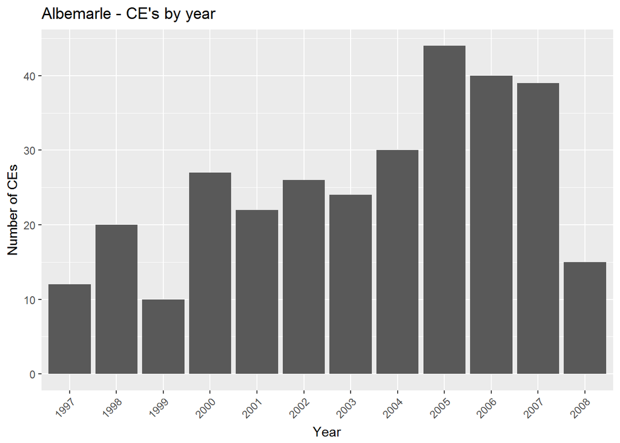

Purpose

```
##                 purpose   n     percent
## 1  Environmental System  23 0.074433657
## 2 Historic Preservation   2 0.006472492
## 3    Open Space - Other 284 0.919093851
```

Data provider

```
##                            datapvdr   n    percent
## 1            The Nature Conservancy  23 0.07443366
## 2 Virginia Natural Heritage Program 286 0.92556634
```

Holder Type

```
##                        eholdtyp   n     percent
## 1              Local Government  72 0.233009709
## 2 Non-Governmental Organization  28 0.090614887
## 3               Regional Agency   2 0.006472492
## 4                         State 207 0.669902913
```

CE Size

```
##   min_acres mean_acres max_acres
## 1  2.257815    209.162  1474.247
```

## Loudoun, VA

In Loudoun county there are a total of 442 conservation easements in the NCED. Looking at just the project timeframe there are 233.  
The breakdown by year is

```r
LDN %>% filter(year_est > 1996 & year_est < 2009) %>% tabyl(year_est)
```

```
##    year_est  n    percent
## 1      1997  4 0.01716738
## 2      1998  5 0.02145923
## 3      1999  4 0.01716738
## 4      2000 17 0.07296137
## 5      2001 30 0.12875536
## 6      2002 40 0.17167382
## 7      2003 18 0.07725322
## 8      2004 15 0.06437768
## 9      2005 22 0.09442060
## 10     2006 41 0.17596567
## 11     2007 17 0.07296137
## 12     2008 20 0.08583691
```

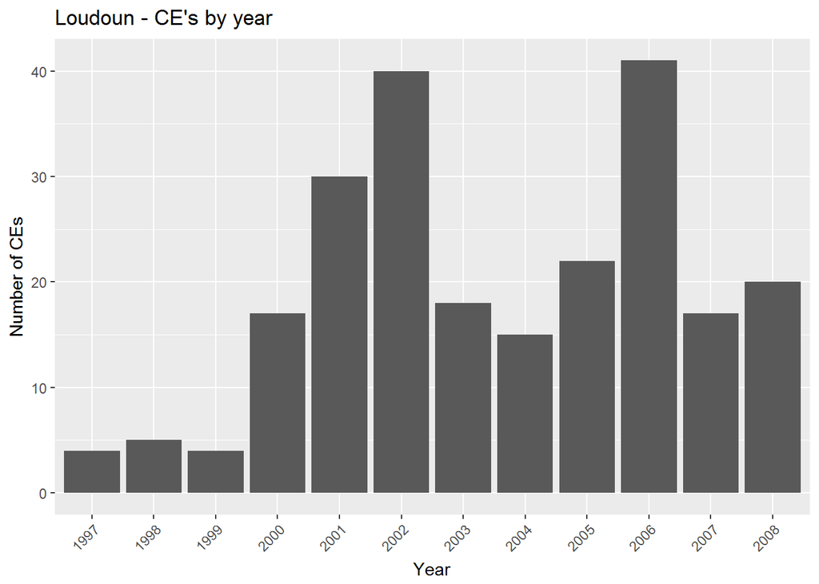

Purpose

```
##                 purpose   n     percent
## 1  Environmental System   3 0.012875536
## 2 Historic Preservation  23 0.098712446
## 3   Open Space - Forest   2 0.008583691
## 4    Open Space - Other 205 0.879828326
```

Data provider

```
##                            datapvdr   n     percent
## 1                   Ducks Unlimited   2 0.008583691
## 2            The Nature Conservancy   1 0.004291845
## 3         Virginia Natural Heritage   5 0.021459227
## 4 Virginia Natural Heritage Program 225 0.965665236
```

Holder Type

```
##                        eholdtyp   n    percent
## 1                  Jointly Held   4 0.01716738
## 2              Local Government  17 0.07296137
## 3 Non-Governmental Organization 107 0.45922747
## 4                         State 105 0.45064378
```

CE Size

```
##   min_acres mean_acres max_acres
## 1 0.1563368   120.6372  1078.163
```

## Greenville, SC

In Greenville county there are a total of 40 conservation easements in the NCED. Looking at just the project timeframe there are 17.  
The breakdown by year is

```r
GVL %>% filter(year_est > 1996 & year_est < 2009) %>% tabyl(year_est)
```

```
##   year_est n    percent
## 1     1998 1 0.05882353
## 2     2001 2 0.11764706
## 3     2002 2 0.11764706
## 4     2004 1 0.05882353
## 5     2005 2 0.11764706
## 6     2006 4 0.23529412
## 7     2007 2 0.11764706
## 8     2008 3 0.17647059
```

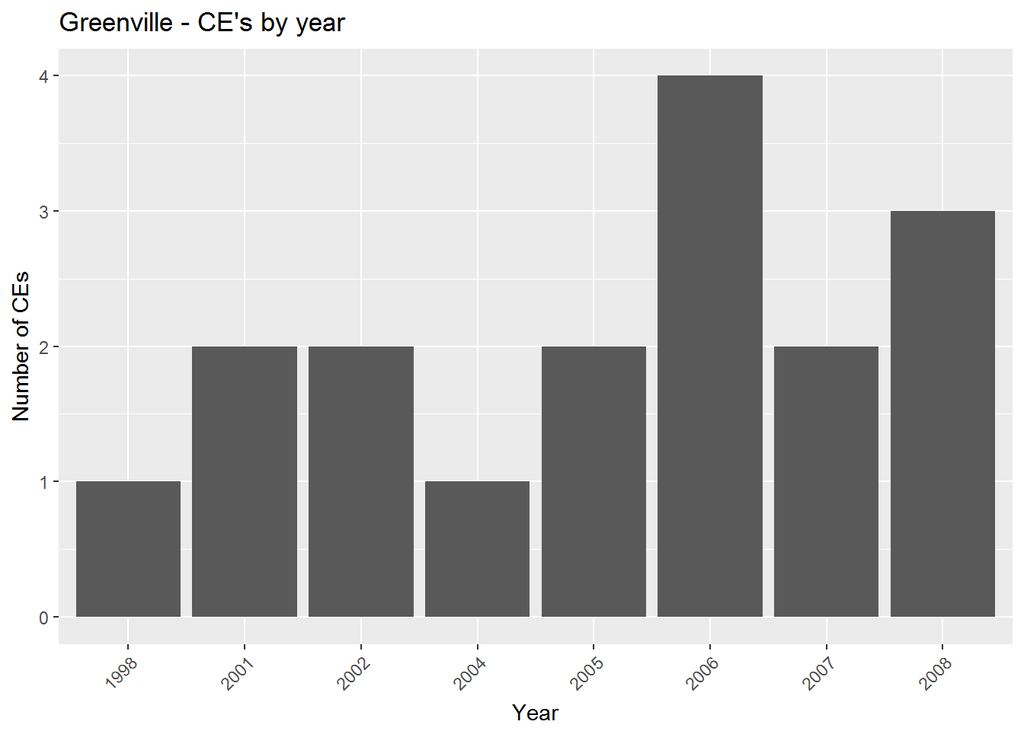

Purpose

```
##                purpose  n percent
## 1 Environmental System 17       1
```

Data provider

```
##                                        datapvdr  n    percent
## 1 GAP_PADUS1_4Easements_NRCS_easement_a_extract  1 0.05882353
## 2              South Carolina Conservation Bank  1 0.05882353
## 3                        The Nature Conservancy  1 0.05882353
## 4                               Upstate Forever 14 0.82352941
```

Holder Type

```
##                        eholdtyp  n    percent
## 1                       Federal  1 0.05882353
## 2 Non-Governmental Organization  2 0.11764706
## 3                         State 14 0.82352941
```

CE Size

```
##   min_acres mean_acres max_acres
## 1 0.8804924   245.7481  1874.991
```

## Charleston, SC

In Charleston county there are a total of 52 conservation easements in the NCED. Looking at just the project timeframe there are 30.  
The breakdown by year is

```r
CHAS %>% filter(year_est > 1996 & year_est < 2009) %>% tabyl(year_est)
```

```
##   year_est n    percent
## 1     1999 5 0.16666667
## 2     2000 3 0.10000000
## 3     2001 1 0.03333333
## 4     2002 4 0.13333333
## 5     2003 2 0.06666667
## 6     2004 3 0.10000000
## 7     2005 3 0.10000000
## 8     2007 8 0.26666667
## 9     2008 1 0.03333333
```

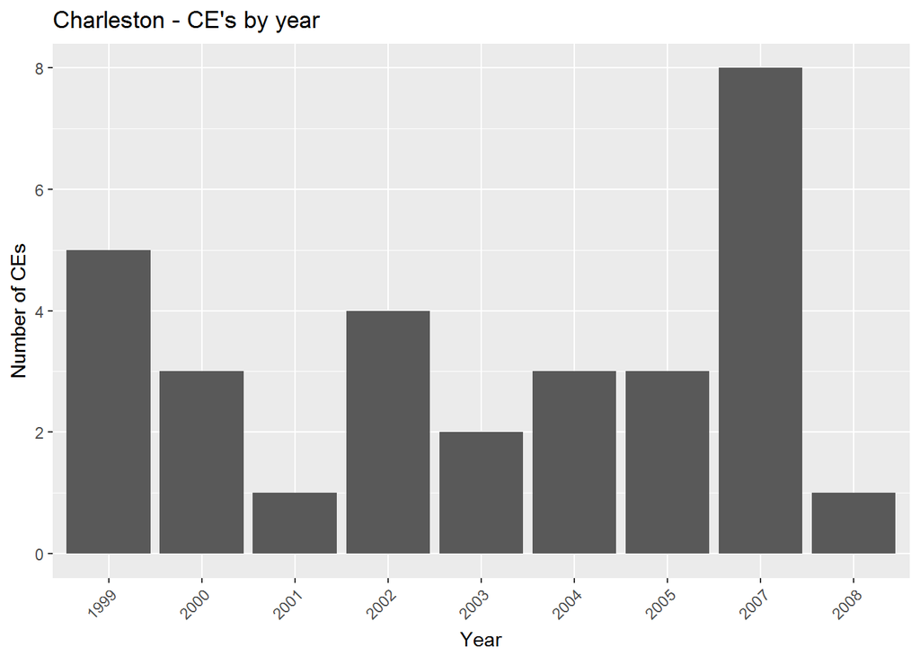

Purpose

```
##                purpose  n    percent
## 1 Environmental System 28 0.93333333
## 2    Open Space - Farm  1 0.03333333
## 3  Open Space - Forest  1 0.03333333
```

Data provider

```
##                                        datapvdr  n    percent
## 1                               Ducks Unlimited 21 0.70000000
## 2 GAP_PADUS1_4Easements_NRCS_easement_a_extract  1 0.03333333
## 3              South Carolina Conservation Bank  1 0.03333333
## 4                        The Nature Conservancy  6 0.20000000
## 5                           U.S. Forest Service  1 0.03333333
```

Holder Type

```
##                        eholdtyp  n    percent
## 1                       Federal  1 0.03333333
## 2                  Jointly Held  1 0.03333333
## 3 Non-Governmental Organization 27 0.90000000
## 4       Unknown Easement Holder  1 0.03333333
```

CE Size

```
##   min_acres mean_acres max_acres
## 1  4.857457   552.9245  5812.358
```

## Douglas, MN

In Douglas county there are a total of 323 conservation easements in the NCED. Looking at just the project timeframe there are 66.  
The breakdown by year is

```r
DGL %>% filter(year_est > 1996 & year_est < 2009) %>% tabyl(year_est)
```

```
##   year_est  n    percent
## 1     1999  2 0.03030303
## 2     2000  4 0.06060606
## 3     2001 10 0.15151515
## 4     2002 33 0.50000000
## 5     2003 10 0.15151515
## 6     2004  4 0.06060606
## 7     2005  1 0.01515152
## 8     2007  1 0.01515152
## 9     2008  1 0.01515152
```

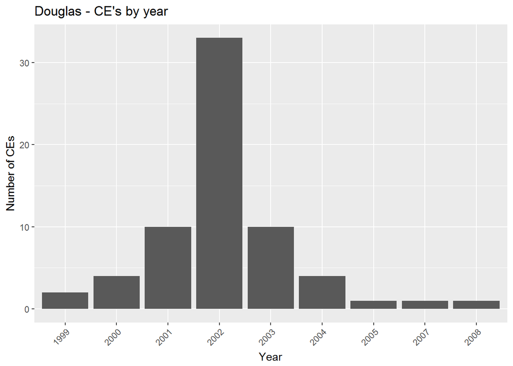

Purpose

```
##                purpose  n percent
## 1 Environmental System 66       1
```

Data provider

```
##                                        datapvdr  n    percent
## 1                               Ducks Unlimited  3 0.04545455
## 2 GAP_PADUS1_4Easements_NRCS_easement_a_extract 11 0.16666667
## 3   Minnesota Board of Water and Soil Resources 51 0.77272727
## 4          Minnesota Land Trust - Mike Robinson  1 0.01515152
```

Holder Type

```
##                        eholdtyp  n    percent
## 1                       Federal  9 0.13636364
## 2                  Jointly Held  3 0.04545455
## 3 Non-Governmental Organization  3 0.04545455
## 4                         State 51 0.77272727
```

CE Size

```
##   min_acres mean_acres max_acres
## 1  3.288784   57.73141   188.587
```

## Washington, MN

In Washington county there are a total of 298 conservation easements in the NCED. Looking at just the project timeframe there are 1.  
The breakdown by year is

```r
WSH  %>% tabyl(year_est)
```

```
##   year_est   n     percent
## 1        0 294 0.986577181
## 2     1987   2 0.006711409
## 3     1993   1 0.003355705
## 4     1999   1 0.003355705
```

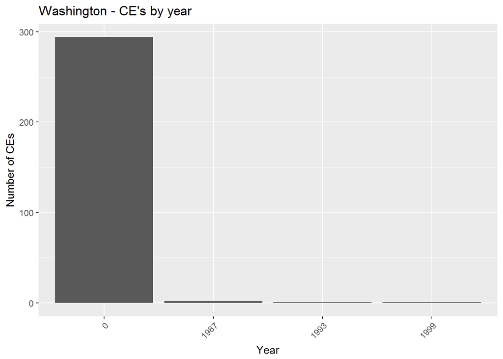

*Due to the lack of CEs in the timeframe and the unknown years ALL CEs are used in the below reports*  
Purpose

```
##                   purpose   n    percent
## 1    Environmental System 290 0.97315436
## 2      Open Space - Other   4 0.01342282
## 3 Recreation or Education   4 0.01342282
```

Data provider

```
##                                      datapvdr   n     percent
## 1            GAP_PADUS1_4Easements_NPS_Tracts   2 0.006711409
## 2 Minnesota Board of Water and Soil Resources   4 0.013422819
## 3                       National Park Service 284 0.953020134
## 4                           Washington County   8 0.026845638
```

Holder Type

```
##           eholdtyp   n     percent
## 1          Federal   1 0.003355705
## 2     Jointly Held   1 0.003355705
## 3 Local Government   8 0.026845638
## 4            State 288 0.966442953
```

CE Size

```
##    min_acres mean_acres max_acres
## 1 0.06937277   7.880827  326.3687
```

## York, PA

In York county there are a total of 278 conservation easements in the NCED. Looking at just the project timeframe there are 190.  
The breakdown by year is

```r
YRK %>% filter(year_est > 1996 & year_est < 2009) %>% tabyl(year_est)
```

```
##    year_est  n    percent
## 1      1997 12 0.06315789
## 2      1998 10 0.05263158
## 3      1999  8 0.04210526
## 4      2000 15 0.07894737
## 5      2001 20 0.10526316
## 6      2002 21 0.11052632
## 7      2003 15 0.07894737
## 8      2004 14 0.07368421
## 9      2005 13 0.06842105
## 10     2006 18 0.09473684
## 11     2007 17 0.08947368
## 12     2008 27 0.14210526
```

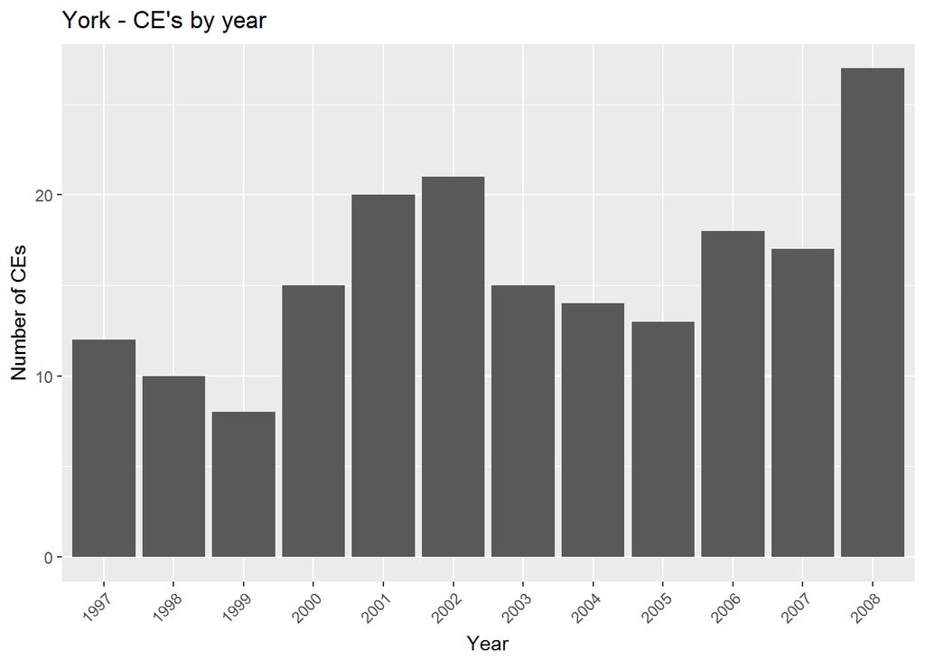

Purpose

```
##             purpose   n percent
## 1 Open Space - Farm 190       1
```

Data provider

```
##                                             datapvdr   n    percent
## 1      GAP_PADUS1_4Easements_NRCS_easement_a_extract   2 0.01052632
## 2                       Maryland Environmental Trust   2 0.01052632
## 3                            PA Dept. of Agriculture   9 0.04736842
## 4 York County Agricultural Land Preservation Program 177 0.93157895
```

Holder Type

```
##           eholdtyp   n     percent
## 1          Federal   1 0.005263158
## 2     Jointly Held   1 0.005263158
## 3 Local Government  68 0.357894737
## 4            State 120 0.631578947
```

CE Size

```
##   min_acres mean_acres max_acres
## 1   13.4278   140.8225  813.9135
```

## Lebanon, PA

In Lebanon county there are a total of 127 conservation easements in the NCED. Looking at just the project timeframe there are 102.  
The breakdown by year is

```r
LEB %>% filter(year_est > 1996 & year_est < 2009) %>% tabyl(year_est)
```

```
##    year_est  n    percent
## 1      1997  2 0.01960784
## 2      1998  6 0.05882353
## 3      1999  4 0.03921569
## 4      2000  8 0.07843137
## 5      2001  9 0.08823529
## 6      2002  3 0.02941176
## 7      2003  6 0.05882353
## 8      2004 18 0.17647059
## 9      2005  6 0.05882353
## 10     2006 16 0.15686275
## 11     2007 10 0.09803922
## 12     2008 14 0.13725490
```

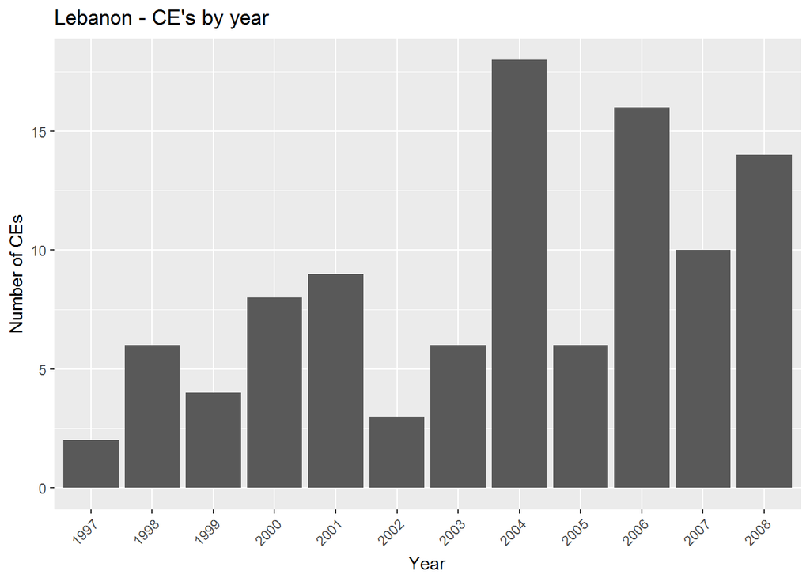

Purpose

```
##             purpose   n percent
## 1 Open Space - Farm 102       1
```

Data provider

```
##                                        datapvdr  n    percent
## 1 GAP_PADUS1_4Easements_NRCS_easement_a_extract  9 0.08823529
## 2                       PA Dept. of Agriculture 93 0.91176471
```

Holder Type

```
##           eholdtyp  n    percent
## 1          Federal  9 0.08823529
## 2 Local Government 93 0.91176471
```

CE Size

```
##   min_acres mean_acres max_acres
## 1  17.81392   116.5613  353.4113
```

## Boulder, CO

In Boulder county there are a total of 567 conservation easements in the NCED. Looking at just the project timeframe there are 360.  
The breakdown by year is

```r
BLD %>% filter(year_est > 1996 & year_est < 2009) %>% tabyl(year_est)
```

```
##    year_est  n    percent
## 1      1997 34 0.09444444
## 2      1998 19 0.05277778
## 3      1999 20 0.05555556
## 4      2000 39 0.10833333
## 5      2001 66 0.18333333
## 6      2002 28 0.07777778
## 7      2003 53 0.14722222
## 8      2004 22 0.06111111
## 9      2005 25 0.06944444
## 10     2006 31 0.08611111
## 11     2007 13 0.03611111
## 12     2008 10 0.02777778
```

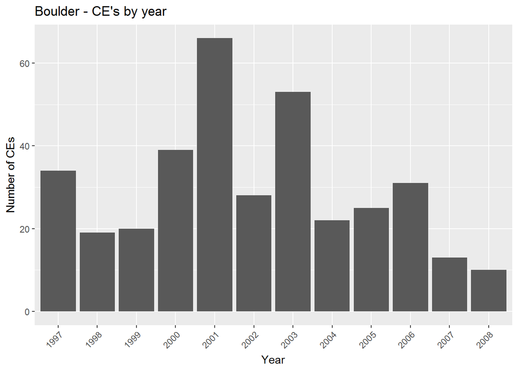

Purpose

```
##                purpose   n     percent
## 1 Environmental System  28 0.077777778
## 2    Open Space - Farm   1 0.002777778
## 3   Open Space - Other  14 0.038888889
## 4   Open Space - Ranch   4 0.011111111
## 5              Unknown 313 0.869444444
```

Data provider

```
##                                                  datapvdr   n     percent
## 1                                          Boulder County 163 0.452777778
## 2                     Boulder County Parks and Open Space 147 0.408333333
## 3                 Broomfield County Open Space and Trails   3 0.008333333
## 4 Colorado Ownership, Management and Protection v9 public   3 0.008333333
## 5          Colorado Ownership, Management, and Protection  37 0.102777778
## 6                                  The Nature Conservancy   7 0.019444444
```

Holder Type

```
##                        eholdtyp   n     percent
## 1                  Jointly Held   3 0.008333333
## 2              Local Government 341 0.947222222
## 3 Non-Governmental Organization  16 0.044444444
```

CE Size

```
##    min_acres mean_acres max_acres
## 1 0.01995958   51.48542  1071.786
```

## Mesa, CO

In Mesa county there are a total of 94 conservation easements in the NCED. Looking at just the project timeframe there are 58.  
The breakdown by year is

```r
MSA %>% filter(year_est > 1996 & year_est < 2009) %>% tabyl(year_est)
```

```
##    year_est  n    percent
## 1      1997  2 0.03448276
## 2      1998  2 0.03448276
## 3      1999  3 0.05172414
## 4      2000  1 0.01724138
## 5      2001  2 0.03448276
## 6      2002  7 0.12068966
## 7      2003  9 0.15517241
## 8      2004  9 0.15517241
## 9      2005  5 0.08620690
## 10     2006 11 0.18965517
## 11     2007  5 0.08620690
## 12     2008  2 0.03448276
```

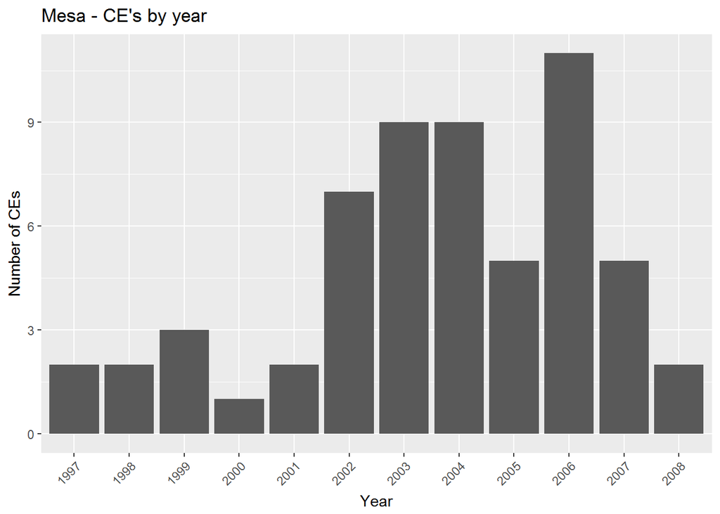

Purpose

```
##                purpose  n   percent
## 1 Environmental System  9 0.1551724
## 2   Open Space - Other 29 0.5000000
## 3   Open Space - Ranch 11 0.1896552
## 4              Unknown  9 0.1551724
```

Data provider

```
##                                                  datapvdr  n    percent
## 1                                 Aspen Valley Land Trust  8 0.13793103
## 2                               Bureau of Land Management  2 0.03448276
## 3 Colorado Ownership, Management and Protection v9 public  2 0.03448276
## 4          Colorado Ownership, Management, and Protection 43 0.74137931
## 5                                 Great Outdoors Colorado  1 0.01724138
## 6                         State of Colorado - State Parks  1 0.01724138
## 7                                  The Nature Conservancy  1 0.01724138
```

Holder Type

```
##                        eholdtyp  n    percent
## 1                       Federal  2 0.03448276
## 2              Local Government  1 0.01724138
## 3 Non-Governmental Organization 50 0.86206897
## 4                         State  5 0.08620690
```

CE Size

```
##   min_acres mean_acres max_acres
## 1  0.441924   317.2489  4530.684
```

## Sacramento, CA

In Sacramento county there are a total of 49 conservation easements in the NCED. Looking at just the project timeframe there are 32.  
The breakdown by year is

```r
SAC %>% filter(year_est > 1996 & year_est < 2009) %>% tabyl(year_est)
```

```
##    year_est n percent
## 1      1997 3 0.09375
## 2      1998 2 0.06250
## 3      1999 2 0.06250
## 4      2000 5 0.15625
## 5      2001 3 0.09375
## 6      2002 3 0.09375
## 7      2003 2 0.06250
## 8      2004 2 0.06250
## 9      2005 1 0.03125
## 10     2006 5 0.15625
## 11     2007 1 0.03125
## 12     2008 3 0.09375
```

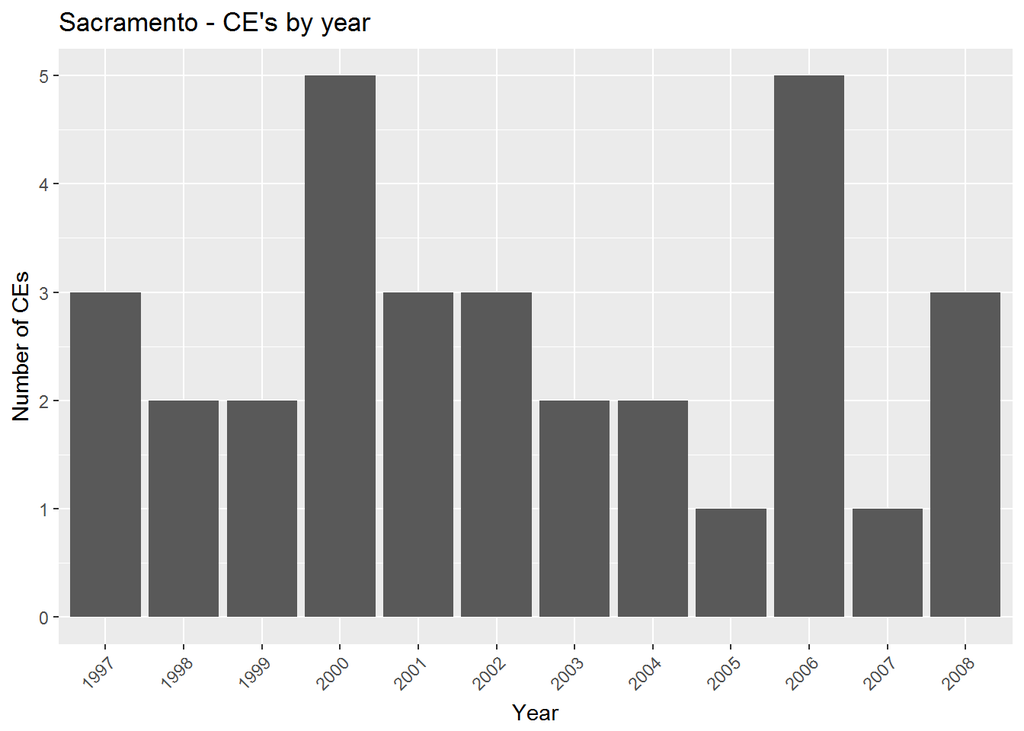

Purpose

```
##                purpose  n percent
## 1 Environmental System 25 0.78125
## 2   Open Space - Other  5 0.15625
## 3              Unknown  2 0.06250
```

Data provider

```
##                                        datapvdr  n percent
## 1 GAP_PADUS1_4Easements_NRCS_easement_a_extract  3 0.09375
## 2                                     NCED 2013  4 0.12500
## 3                        The Nature Conservancy 16 0.50000
## 4                  Wildlife Heritage Foundation  9 0.28125
```

Holder Type

```
##                        eholdtyp  n percent
## 1                       Federal  7 0.21875
## 2 Non-Governmental Organization 25 0.78125
```

CE Size

```
##   min_acres mean_acres max_acres
## 1 0.8762877   427.3841  5302.604
```

## Sonoma, CA

In Sonoma county there are a total of 352 conservation easements in the NCED. Looking at just the project timeframe there are 100.  
The breakdown by year is

```r
SON %>% filter(year_est > 1996 & year_est < 2009) %>% tabyl(year_est)
```

```
##    year_est  n percent
## 1      1997  6    0.06
## 2      1998  9    0.09
## 3      1999  8    0.08
## 4      2000  6    0.06
## 5      2001  3    0.03
## 6      2002 13    0.13
## 7      2003 15    0.15
## 8      2004 13    0.13
## 9      2005  9    0.09
## 10     2006  4    0.04
## 11     2007  9    0.09
## 12     2008  5    0.05
```

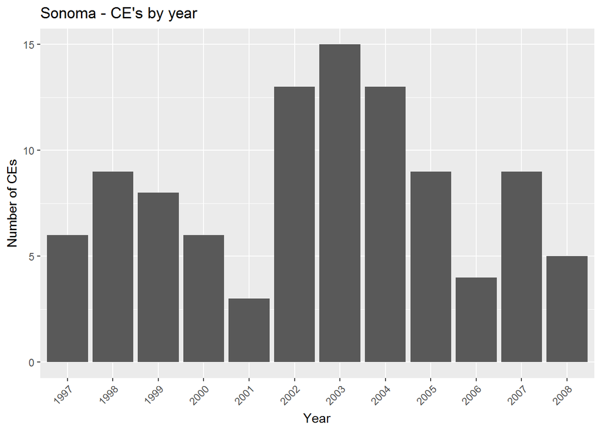

Purpose

```
##                   purpose  n percent
## 1    Environmental System 21    0.21
## 2   Historic Preservation  1    0.01
## 3       Open Space - Farm 17    0.17
## 4     Open Space - Forest  6    0.06
## 5      Open Space - Other 18    0.18
## 6      Open Space - Ranch  4    0.04
## 7 Recreation or Education 23    0.23
## 8                 Unknown 10    0.10
```

Data provider

```
##                                        datapvdr  n percent
## 1 GAP_PADUS1_4Easements_NRCS_easement_a_extract  1    0.01
## 2          Golden State Land Conservancy (GSLC) 17    0.17
## 3                             GreenInfo Network 78    0.78
## 4                                Humane Society  1    0.01
## 5                                 Sonoma County  1    0.01
## 6                        The Nature Conservancy  1    0.01
## 7                  Wildlife Heritage Foundation  1    0.01
```

Holder Type

```
##                        eholdtyp  n percent
## 1                       Federal  1    0.01
## 2              Local Government 53    0.53
## 3 Non-Governmental Organization 31    0.31
## 4               Regional Agency 15    0.15
```

CE Size

```
##   min_acres mean_acres max_acres
## 1  0.410028   421.3838  10483.21
```